# A1_54007301

- Show All Code
- Hide All Code
- View Source

Author

540007301

Published

27 March, 2026

```r
library(Biobase)
library(limma)
library(kableExtra)
library(ggplot2)
library(caret)
library(randomForest)
library(pROC)
```

# Introduction.

This report investigates whether blood-based (GSE46474) or biopsy-based (GSE138043) gene expression samples lead to better classification of kidney graft rejection. Part 1 identifies the top differentially expressed genes in each dataset using limma. Part 2 visualises all features via volcano plots. Part 3 builds Random Forest classifiers evaluated with LOOCV, and compares their performance to determine which sample type is more suitable for clinical deployment.

# Part 1: Exploratory Analysis

## Data pre-processing

```r
load("GSE138043.RData")
gse138043 <- gse

load("GSE46474.RData")
gse46474 <- gse

expr1 <- exprs(gse138043)
pd1 <- pData(gse138043)
fd1 <- fData(gse138043)

expr2 <- exprs(gse46474)
pd2 <- pData(gse46474)
fd2 <- fData(gse46474)
```

This section first conducts pre-processing on the existing data by - formatting nas and empty inputs as NA_character - conduct name/symbol extraction by splitting certain specific columns when “///” or “//” were used. Furthermore, for cases where multiple probes reacted, that section would be disregarded, as these cases indicate that it is ambiguous which probe has reacted, and thus means that the result is not trustworthy.

```r
extract_symbols_fd1 <- function(x) {
  if (is.na(x) || x == "") return(character(0))

  parts <- unlist(strsplit(x, " /// "))

  syms <- vapply(parts, function(part) {
    fields <- unlist(strsplit(part, " // "))
    if (length(fields) >= 2) fields[2] else NA_character_
  }, character(1))

  syms <- unique(na.omit(syms))
  syms <- syms[syms != ""]
  syms
}

extract_unique_symbol_fd1 <- function(x) {
  syms <- extract_symbols_fd1(x)
  if (length(syms) == 1) syms else NA_character_
}

extract_symbols_fd2 <- function(x) {
  if (is.na(x) || x == "") return(character(0))

  parts <- unlist(strsplit(x, " /// "))
  parts <- trimws(parts)
  parts <- unique(parts)
  parts <- parts[parts != ""]
  parts
}


extract_unique_symbol_fd2 <- function(x) {
  syms <- extract_symbols_fd2(x)
  if (length(syms) == 1) syms else NA_character_
}
```

Then necessary data from biopsy-based samples (gse138043) and blood-based samples (gse46474) were extracted to from group1 and group2 respectively. group1 consists of the AR/non-AR result of of the biopsy-based samples whilst group2 consists the same but for blood-based samples.

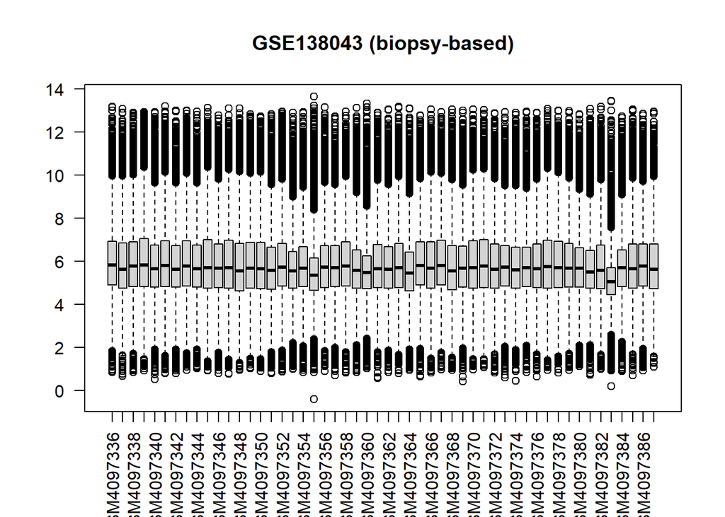

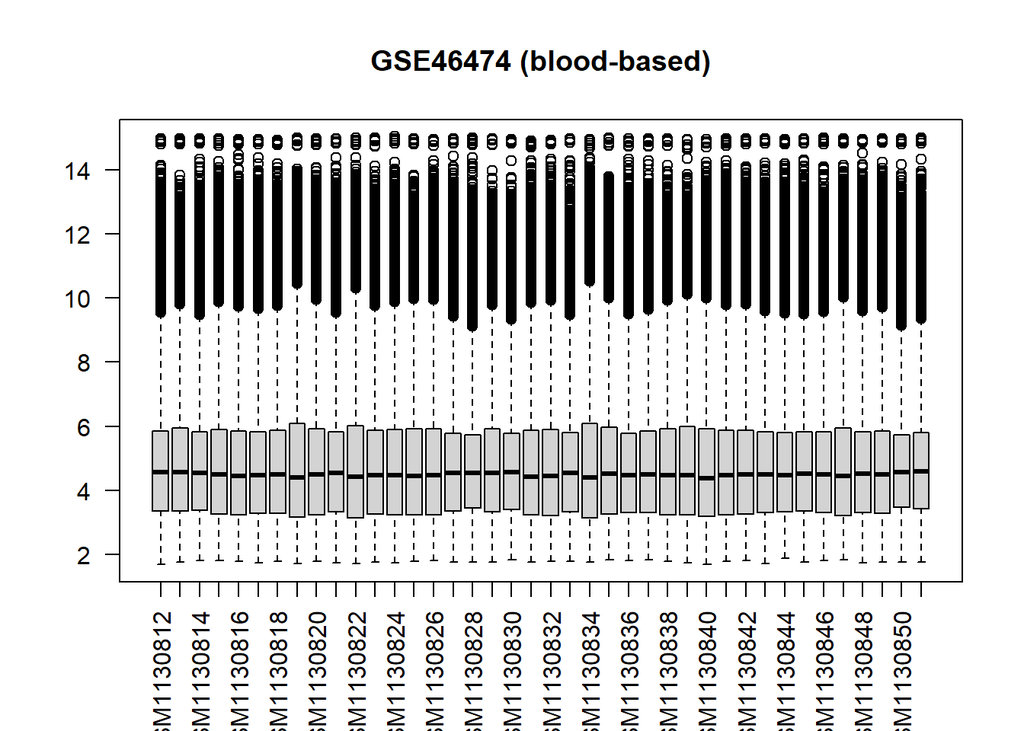

Further, normality and variance was tested for both biopsy and blood based sample via a box plot, which seems to suggest somewhat of a skew and not perfect normality. However, as can be seen from below, both data are roughly log-scaled which suggest that the use of limma pipeline, which does not rely on strict normality, is sensible and thus we can proceed.

```r
summary(as.vector(expr1))
```

```
   Min. 1st Qu.  Median    Mean 3rd Qu.    Max.
-0.3995  4.7688  5.6523  5.8168  6.7541 13.6486
```

```r
summary(as.vector(expr2))
```

```
   Min. 1st Qu.  Median    Mean 3rd Qu.    Max.
  1.677   3.279   4.488   4.755   5.863  15.045
```

## Finding the most differential genes

In the below process, it takes the pData of biopsy-based samples and differentiates them into AR and non-AR and designs a matrix using those data. Then it fits every gene in to a linear model and compares which of the genes has the largest fold change using makeContrast function. The final output ensures that the top 20 genes are all unique as one gene may be represented by multiple probes on a micro array.

```r
#gse138043

group1 <- factor(pd1[["rejection at 12months post transplant:ch1"]])
group1_clean <- factor(make.names(as.character(group1)))

design1 <- model.matrix(~ 0 + group1_clean)
colnames(design1) <- levels(group1_clean)

rfit1 <- lmFit(expr1, design1)
cont1 <- makeContrasts(AR - non.AR, levels = design1)
fit1 <- contrasts.fit(rfit1, cont1)
fit1 <- eBayes(fit1)

res1 <- topTable(fit1, number = Inf, adjust.method = "BH")

res1$GeneSymbol <- vapply(
  fd1[rownames(res1), "gene_assignment"],
  extract_unique_symbol_fd1,
  character(1)
)

res1_clean <- res1[!is.na(res1$GeneSymbol) & res1$GeneSymbol != "", ]

res1_clean <- res1_clean[order(res1_clean$adj.P.Val, -abs(res1_clean$logFC)), ]

res1_unique <- res1_clean[!duplicated(res1_clean$GeneSymbol), ]

top20_table1 <- res1_unique[1:20, c("GeneSymbol", "logFC", "adj.P.Val", "P.Value", "t", "B")]
top20_table1
```

```
        GeneSymbol      logFC    adj.P.Val      P.Value         t         B
3066751      SYPL1 -0.4904574 0.0001036679 6.139647e-09 -6.900930 10.089996
2590736     NCKAP1 -0.6448322 0.0012177108 2.163537e-07 -5.940647  6.840583
2337716     PRKAA2 -0.7937267 0.0013323846 3.156375e-07 -5.837797  6.495354
2380785    LYPLAL1 -0.9212765 0.0016306166 6.760033e-07 -5.629403  5.799011
2485176       MDH1 -0.7090667 0.0016306166 6.604425e-07 -5.635797  5.820305
2395146    TNFRSF9  0.4831155 0.0016306166 6.067596e-07  5.659061  5.897826
2620018    C3orf23 -0.7316497 0.0016354833 7.748810e-07 -5.591891  5.674183
3959986      IL2RB  0.5862778 0.0017549402 9.354138e-07  5.540067  5.502014
3011861     STEAP2 -0.6172214 0.0017676726 1.256267e-06 -5.458679  5.232340
2752478      WDR17 -0.5906784 0.0017676726 1.169960e-06 -5.478346  5.297424
2548776       ATL2 -0.5796947 0.0020649396 1.589826e-06 -5.393492  5.017020
3652218     UQCRC2 -0.5338131 0.0023945915 1.985447e-06 -5.331803  4.813837
2722291    TBC1D19 -0.7548064 0.0024690578 2.677357e-06 -5.248521  4.540495
2635641      PVRL3 -0.7521744 0.0024690578 2.377928e-06 -5.281597  4.648918
2914820     BCKDHB -0.6488387 0.0024690578 2.924558e-06 -5.223856  4.459764
3881651        HCK  0.4799109 0.0024690578 2.878648e-06  5.228278  4.474228
3657041      ITGAX  0.4553396 0.0024690578 2.606079e-06  5.256051  4.565162
3332663        CD6  0.3679254 0.0024690578 2.652931e-06  5.251079  4.548873
2719440    C1QTNF7 -0.6481760 0.0025736188 3.484170e-06 -5.174865  4.299725
2366422     ATP1B1 -0.6017818 0.0025736188 3.505670e-06 -5.173141  4.294103
```

The same process has been conducted on the blood-based samples as well.

```r
#gse46474
group2 <- factor(pd2[["procedure status:ch1"]])
group2_clean <- factor(make.names(as.character(group2)))

design2 <- model.matrix(~ 0 + group2_clean)
colnames(design2) <- levels(group2_clean)

fit2 <- lmFit(expr2, design2)
cont2 <- makeContrasts(
  post.transplant.acute.rejection..AR. - post.transplant.non.rejection..NR.,
  levels = design2
)
fit2 <- contrasts.fit(fit2, cont2)
fit2 <- eBayes(fit2)

res2 <- topTable(fit2, number = Inf, adjust.method = "BH")

res2$GeneSymbol <- vapply(
  fd2[rownames(res2), "Gene Symbol"],
  extract_unique_symbol_fd2,
  character(1)
)
res2_clean <- res2[!is.na(res2$GeneSymbol) & res2$GeneSymbol != "", ]

res2_clean <- res2_clean[order(res2_clean$adj.P.Val, -abs(res2_clean$logFC)), ]

res2_unique <- res2_clean[!duplicated(res2_clean$GeneSymbol), ]

top20_table2 <- res2_unique[1:20, c("GeneSymbol", "logFC", "adj.P.Val", "P.Value", "t", "B")]
```

Below are the final results for biopsy and blood based samples respectively.

biopsy-based:

|  | GeneSymbol | logFC | adj.P.Val | P.Value | t | B |
| --- | --- | --- | --- | --- | --- | --- |
| 3066751 | SYPL1 | -0.4904574 | 0.0001037 | 0.0e+00 | -6.900930 | 10.089996 |
| 2590736 | NCKAP1 | -0.6448322 | 0.0012177 | 2.0e-07 | -5.940647 | 6.840583 |
| 2337716 | PRKAA2 | -0.7937267 | 0.0013324 | 3.0e-07 | -5.837797 | 6.495354 |
| 2380785 | LYPLAL1 | -0.9212765 | 0.0016306 | 7.0e-07 | -5.629403 | 5.799011 |
| 2485176 | MDH1 | -0.7090667 | 0.0016306 | 7.0e-07 | -5.635797 | 5.820305 |
| 2395146 | TNFRSF9 | 0.4831155 | 0.0016306 | 6.0e-07 | 5.659061 | 5.897826 |
| 2620018 | C3orf23 | -0.7316497 | 0.0016355 | 8.0e-07 | -5.591891 | 5.674183 |
| 3959986 | IL2RB | 0.5862778 | 0.0017549 | 9.0e-07 | 5.540067 | 5.502014 |
| 3011861 | STEAP2 | -0.6172214 | 0.0017677 | 1.3e-06 | -5.458679 | 5.232340 |
| 2752478 | WDR17 | -0.5906784 | 0.0017677 | 1.2e-06 | -5.478346 | 5.297424 |
| 2548776 | ATL2 | -0.5796947 | 0.0020649 | 1.6e-06 | -5.393492 | 5.017020 |
| 3652218 | UQCRC2 | -0.5338131 | 0.0023946 | 2.0e-06 | -5.331803 | 4.813837 |
| 2722291 | TBC1D19 | -0.7548064 | 0.0024691 | 2.7e-06 | -5.248521 | 4.540495 |
| 2635641 | PVRL3 | -0.7521744 | 0.0024691 | 2.4e-06 | -5.281597 | 4.648918 |
| 2914820 | BCKDHB | -0.6488387 | 0.0024691 | 2.9e-06 | -5.223856 | 4.459765 |
| 3881651 | HCK | 0.4799109 | 0.0024691 | 2.9e-06 | 5.228278 | 4.474228 |
| 3657041 | ITGAX | 0.4553396 | 0.0024691 | 2.6e-06 | 5.256051 | 4.565162 |
| 3332663 | CD6 | 0.3679254 | 0.0024691 | 2.7e-06 | 5.251079 | 4.548873 |
| 2719440 | C1QTNF7 | -0.6481760 | 0.0025736 | 3.5e-06 | -5.174865 | 4.299725 |
| 2366422 | ATP1B1 | -0.6017818 | 0.0025736 | 3.5e-06 | -5.173141 | 4.294103 |

blood-based:

|  | GeneSymbol | logFC | adj.P.Val | P.Value | t | B |
| --- | --- | --- | --- | --- | --- | --- |
| 210686_x_at | SLC25A16 | 0.7555083 | 0.0008488 | 0.00e+00 | 6.791756 | 8.245293 |
| 202028_s_at | RPL38 | 0.8933696 | 0.0022775 | 1.00e-07 | 6.353216 | 7.012077 |
| 211454_x_at | FKSG49 | 0.8058183 | 0.0057419 | 9.00e-07 | 5.752298 | 5.306122 |
| 1558113_at | FAM78B | -0.4817294 | 0.0070037 | 1.40e-06 | -5.638630 | 4.982695 |
| 218157_x_at | CDC42SE1 | 0.7062254 | 0.0123262 | 2.70e-06 | 5.431333 | 4.393291 |
| 212044_s_at | RPL27A | 0.7505249 | 0.0129468 | 3.10e-06 | 5.391788 | 4.280980 |
| 218342_s_at | ERMP1 | -0.4251964 | 0.0143072 | 3.80e-06 | -5.328975 | 4.102718 |
| 1566342_at | SOD2 | 1.0762434 | 0.0170582 | 6.00e-06 | 5.187311 | 3.701379 |
| 1563796_s_at | EARS2 | -0.3959416 | 0.0170582 | 5.60e-06 | -5.209738 | 3.764838 |
| 209927_s_at | CHTOP | 0.4484731 | 0.0171504 | 7.00e-06 | 5.140051 | 3.567755 |
| 219140_s_at | RBP4 | 0.5220070 | 0.0196458 | 8.60e-06 | 5.074986 | 3.384045 |
| 208518_s_at | PER2 | -0.3689064 | 0.0202140 | 9.30e-06 | -5.053556 | 3.323610 |
| 202236_s_at | SLC16A1 | -0.4833021 | 0.0227416 | 1.08e-05 | -5.004959 | 3.186698 |
| 213826_s_at | H3F3A | 0.8504890 | 0.0228504 | 1.33e-05 | 4.940504 | 3.005434 |
| 213799_s_at | PTPRA | -0.4873878 | 0.0228504 | 1.20e-05 | -4.973851 | 3.099168 |
| 214442_s_at | PIAS2 | -0.4797236 | 0.0228504 | 1.30e-05 | -4.947849 | 3.026072 |
| 203294_s_at | LMAN1 | -0.3497498 | 0.0228504 | 1.37e-05 | -4.931023 | 2.978804 |
| 1555894_s_at | MTSS1L | -0.4202349 | 0.0271438 | 1.81e-05 | -4.845126 | 2.737960 |
| 202344_at | HSF1 | 0.3907095 | 0.0308624 | 2.20e-05 | 4.783852 | 2.566650 |
| 205120_s_at | SGCB | 0.4285802 | 0.0327006 | 2.45e-05 | 4.750116 | 2.472520 |

Further, by testing the overlap between blood based and biopsy based samples, it shows that there are no overlaps at all and thus the top 20 for each are completely different sets of genes.

# Part 2. Visualization

Volcano plots are used below to visualise all probes simultaneously for both the biopsy-based (p1) and blood-based (p2) datasets. The x-axis shows the log2 fold change (magnitude of differential expression) and the y-axis shows the -log10 p-value (statistical significance). Genes in the upper-right and upper-left corners are both highly significant and strongly differentially expressed, making them the most relevant candidates. This visualisation was chosen because it efficiently displays both effect size and significance for every feature in a single plot, allowing quick identification of potentially important genes.

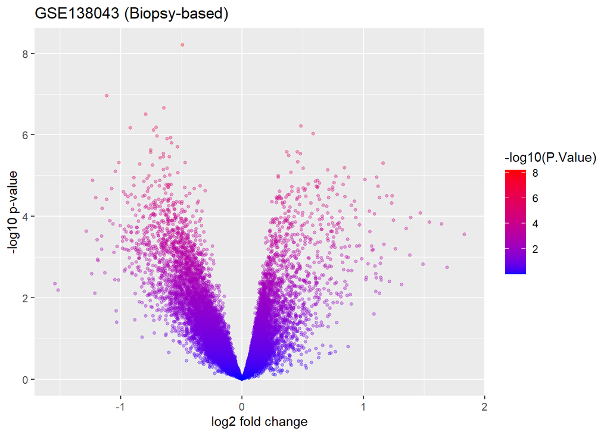

```r
p1 <- ggplot(res1, aes(logFC,-log10(P.Value)))+
    geom_point(aes(colour=-log10(P.Value)), alpha=1/3, size=1) +
    scale_colour_gradient(low="blue",high="red")+
    xlab("log2 fold change") + ylab("-log10 p-value") +
    ggtitle("GSE138043 (Biopsy-based)")
p2 <- ggplot(res2, aes(logFC,-log10(P.Value)))+
    geom_point(aes(colour=-log10(P.Value)), alpha=1/3, size=1) +
    scale_colour_gradient(low="blue",high="red")+
    xlab("log2 fold change") + ylab("-log10 p-value") +
    ggtitle("GSE46474 (Blood-based)")
p1
```

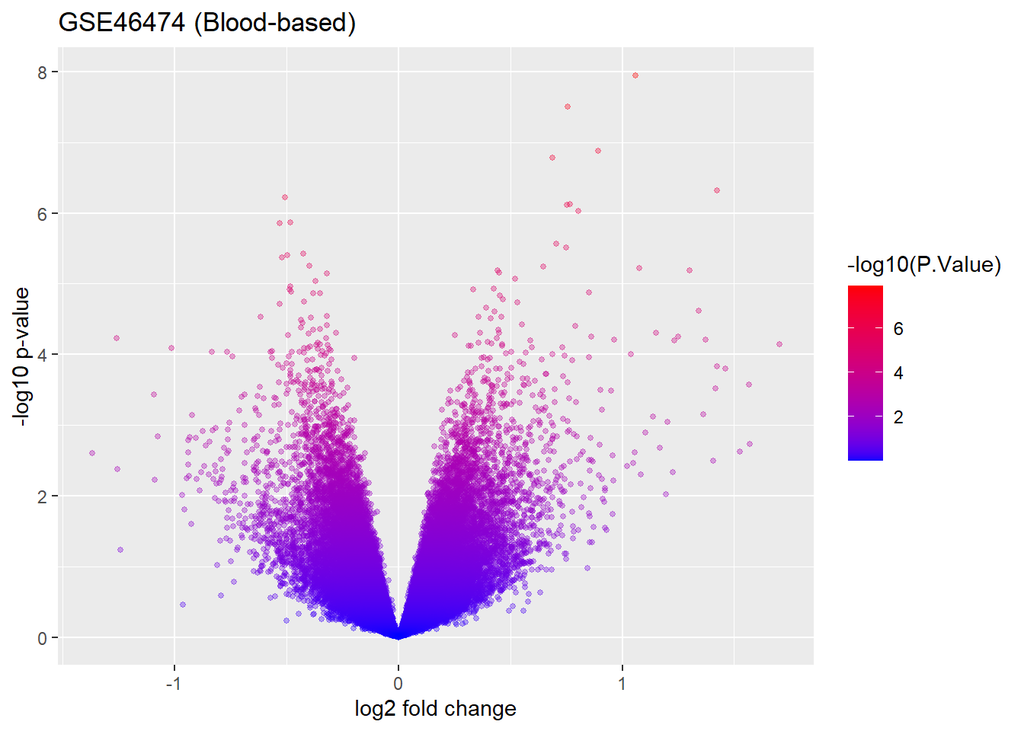

```r
p2
```

# Part 3: Model + Evaluation

The first is the model for the biopsy based samples, put into a random forest classification model. The model was chosen aboves the likes of k-means/kNN models due to the data set’s nature of having high dimension and is robust to multicollinearity. Further, (Leave-one-out-cross-validation)LOOCV a specific kind of cross-validation technique was used to prevent over fitting. LOOCV, unlike a usual k-fold CV only leaves one sample out when validating, making the process more suitable for a relatively small samples size data, like the ones dealt in this case. By going through LOOCV process, the data is capable of testing on an “unknown” data, which the model in real life will be used on.

```r
set.seed(42)
actual_classes1 <- factor(make.names(as.character(pd1[["rejection at 12months post transplant:ch1"]])))
n_samples <- ncol(expr1)
predictions1 <- character(n_samples)
prob_scores1 <- numeric(n_samples)
positive_class1 <- levels(actual_classes1)[1]  # "AR"
for (i in 1:n_samples) {
  train_expr <- expr1[, -i]
  test_expr <- expr1[, i, drop = FALSE]

  train_group <- actual_classes1[-i]
  test_group <- actual_classes1[i]

  design_train <- model.matrix(~ 0 + train_group)
  colnames(design_train) <- levels(train_group)

  fit_train <- lmFit(train_expr, design_train)
  cont_train <- makeContrasts(AR - non.AR, levels = design_train)
  fit_train <- contrasts.fit(fit_train, cont_train)
  fit_train <- eBayes(fit_train)

  res_train <- topTable(fit_train, number = Inf, adjust.method = "BH")
  res_train$GeneSymbol <- vapply(
    fd1[rownames(res_train), "gene_assignment"],
    extract_unique_symbol_fd1,
    character(1)
  )
  res_train_clean <- res_train[!is.na(res_train$GeneSymbol) & res_train$GeneSymbol != "", ]
  res_train_clean <- res_train_clean[order(res_train_clean$adj.P.Val, -abs(res_train_clean$logFC)), ]
  res_train_unique <- res_train_clean[!duplicated(res_train_clean$GeneSymbol), ]

  top20_probes_fold <- head(rownames(res_train_unique), 20)

  train_rf_data <- data.frame(t(train_expr[top20_probes_fold, ]), Status = train_group)
  colnames(train_rf_data) <- make.names(colnames(train_rf_data))

  test_rf_data <- data.frame(t(test_expr[top20_probes_fold, , drop = FALSE]))
  colnames(test_rf_data) <- make.names(colnames(test_rf_data))

  rf_model <- randomForest(Status ~ ., data = train_rf_data, ntree = 500)

  fold_prediction <- predict(rf_model, newdata = test_rf_data)
  predictions1[i] <- as.character(fold_prediction)

  fold_prob <- predict(rf_model, newdata = test_rf_data, type = "vote")
  prob_scores1[i] <- fold_prob[1, positive_class1]
}

predictions1 <- factor(predictions1, levels = levels(actual_classes1))
```

An identical model was used for blood-based samples as well, using random forest and LOOCV.

```r
set.seed(42)
actual_classes2 <- factor(make.names(as.character(pd2[["procedure status:ch1"]])))
n_samples <- ncol(expr2)
predictions2 <- character(n_samples)
prob_scores2 <- numeric(n_samples)
positive_class2 <- levels(actual_classes2)[1]
for (i in 1:n_samples) {
  train_expr <- expr2[, -i]
  test_expr <- expr2[, i, drop = FALSE]

  train_group <- actual_classes2[-i]
  test_group <- actual_classes2[i]

  design_train <- model.matrix(~ 0 + train_group)
  colnames(design_train) <- levels(train_group)

  fit_train <- lmFit(train_expr, design_train)
  cont_train <- makeContrasts(
  post.transplant.acute.rejection..AR. - post.transplant.non.rejection..NR.,
  levels = design_train
  )
  fit_train <- contrasts.fit(fit_train, cont_train)
  fit_train <- eBayes(fit_train)

  res_train <- topTable(fit_train, number = Inf, adjust.method = "BH")

  res_train$GeneSymbol <- vapply(
    fd2[rownames(res_train), "Gene Symbol"],
    extract_unique_symbol_fd2,
    character(1)
  )

  res_train_clean <- res_train[!is.na(res_train$GeneSymbol) & res_train$GeneSymbol != "", ]
  res_train_clean <- res_train_clean[order(res_train_clean$adj.P.Val, -abs(res_train_clean$logFC)), ]
  res_train_unique <- res_train_clean[!duplicated(res_train_clean$GeneSymbol), ]

  top20_probes_fold <- head(rownames(res_train_unique), 20)

  train_rf_data <- data.frame(t(train_expr[top20_probes_fold, ]), Status = train_group)
  colnames(train_rf_data) <- make.names(colnames(train_rf_data))

  test_rf_data <- data.frame(t(test_expr[top20_probes_fold, , drop = FALSE]))
  colnames(test_rf_data) <- make.names(colnames(test_rf_data))

  rf_model <- randomForest(Status ~ ., data = train_rf_data, ntree = 500)

  fold_prediction <- predict(rf_model, newdata = test_rf_data)
  predictions2[i] <- as.character(fold_prediction)

  fold_prob <- predict(rf_model, newdata = test_rf_data, type = "vote")
  prob_scores2[i] <- fold_prob[1, positive_class2]
}

predictions2 <- factor(predictions2, levels = levels(actual_classes2))
```

Based on it, below are the results from each of the models.

Biopsy based model

```
Confusion Matrix and Statistics

          Reference
Prediction AR non.AR
    AR      9      2
    non.AR  6     35

               Accuracy : 0.8462
                 95% CI : (0.7192, 0.9312)
    No Information Rate : 0.7115
    P-Value [Acc > NIR] : 0.01893

                  Kappa : 0.593

 Mcnemar's Test P-Value : 0.28884

            Sensitivity : 0.6000
            Specificity : 0.9459
         Pos Pred Value : 0.8182
         Neg Pred Value : 0.8537
             Prevalence : 0.2885
         Detection Rate : 0.1731
   Detection Prevalence : 0.2115
      Balanced Accuracy : 0.7730

       'Positive' Class : AR
```

blood based model

```
Confusion Matrix and Statistics

                                      Reference
Prediction                             post.transplant.acute.rejection..AR.
  post.transplant.acute.rejection..AR.                                   16
  post.transplant.non.rejection..NR.                                      4
                                      Reference
Prediction                             post.transplant.non.rejection..NR.
  post.transplant.acute.rejection..AR.                                  5
  post.transplant.non.rejection..NR.                                   15

               Accuracy : 0.775
                 95% CI : (0.6155, 0.8916)
    No Information Rate : 0.5
    P-Value [Acc > NIR] : 0.0003398

                  Kappa : 0.55

 Mcnemar's Test P-Value : 1.0000000

            Sensitivity : 0.8000
            Specificity : 0.7500
         Pos Pred Value : 0.7619
         Neg Pred Value : 0.7895
             Prevalence : 0.5000
         Detection Rate : 0.4000
   Detection Prevalence : 0.5250
      Balanced Accuracy : 0.7750

       'Positive' Class : post.transplant.acute.rejection..AR.
```

## ROC Curves

Below are the ROC curves for both models, which plot the true positive rate against the false positive rate at various classification thresholds. the arc shape on both indicates that both have high sensitivity + few false alarms, and that both models in this perspective is not severely different.

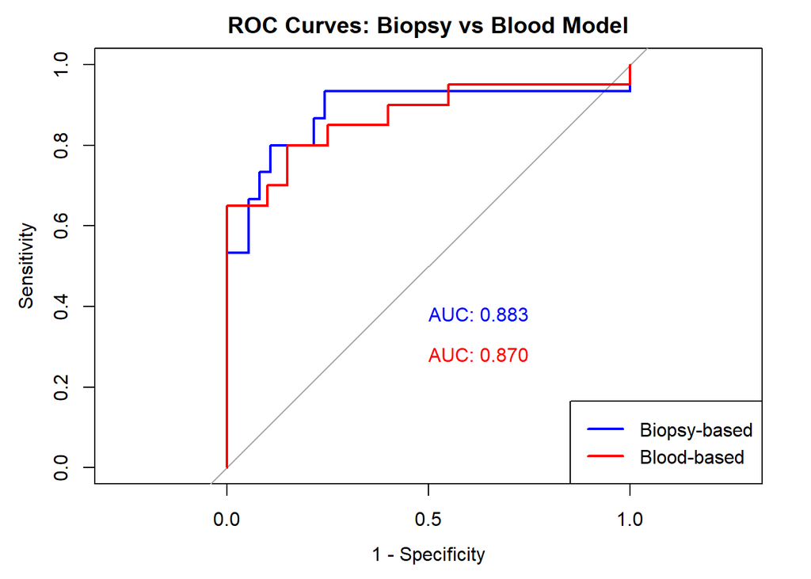

# Conclusion

Overall, the blood-based model is likely more reliable than the biopsy-based model due to its more balanced sensitivity and specificity, though both have room for improvement. LOOCV was chosen because it maximises training data in each fold, which is appropriate for these small sample sizes. However, LOOCV estimates can have high variance, so the reported accuracies should be interpreted with caution. Increasing the sample size would help produce more stable and generalisable performance estimates.